# Portfolio Backtesting

Daniel P. Palomar and Rui ZHOU Hong Kong University of Science and Technology (HKUST)

2019-02-24

> This vignette illustrates the usage of the package `portfolioBacktest` for automated portfolio backtesting. It can be used by a researcher/practitioner to check a set of different portfolios, as well as by a course instructor to evaluate the students in their portfolio design in a fully automated and convenient manner.

# Installation

The package can currently be installed from [GitHub](https://github.com/dppalomar/portfolioBacktest):

```r
# install.packages("devtools")
devtools::install_github("dppalomar/portfolioBacktest")

# Getting help
library(portfolioBacktest)
help(package = "portfolioBacktest")
package?portfolioBacktest
?portfolioBacktest
```

# Usage of the package

## Loading data

We start by loading the package and some random sets of stock market data:

```r
library(PerformanceAnalytics)
library(portfolioBacktest)
data(dataset)
```

The dataset `dataset` is a list of data that contains the prices of random sets of stock market data from the S&P 500, over random periods of two years with a random selection of 50 stocks of each universe.

```r
length(dataset)
```

```
#> [1] 10
```

```r
names(dataset[[1]])
```

```
#> [1] "open"     "high"     "low"      "close"    "volume"   "adjusted"
#> [7] "index"
```

```r
str(dataset[[1]]$adjusted)
```

```
#> An 'xts' object on 2015-04-24/2017-04-24 containing:
#>   Data: num [1:504, 1:50] 22.1 22.1 22.7 22.5 22.3 ...
#>  - attr(*, "dimnames")=List of 2
#>   ..$ : NULL
#>   ..$ : chr [1:50] "MAS.Adjusted" "MGM.Adjusted" "CMI.Adjusted" "CSX.Adjusted" ...
#>   Indexed by objects of class: [Date] TZ: UTC
#>   xts Attributes:
#> List of 2
#>  $ src    : chr "yahoo"
#>  $ updated: POSIXct[1:1], format: "2018-12-29 16:24:41"
```

```r
colnames(dataset[[1]]$adjusted)
```

```
#>  [1] "MAS.Adjusted"  "MGM.Adjusted"  "CMI.Adjusted"  "CSX.Adjusted"
#>  [5] "TGT.Adjusted"  "AWK.Adjusted"  "LNC.Adjusted"  "KO.Adjusted"
#>  [9] "CCI.Adjusted"  "RJF.Adjusted"  "ICE.Adjusted"  "SRE.Adjusted"
#> [13] "FOXA.Adjusted" "CERN.Adjusted" "ORLY.Adjusted" "EMR.Adjusted"
#> [17] "CME.Adjusted"  "AVB.Adjusted"  "AMT.Adjusted"  "TIF.Adjusted"
#> [21] "HAL.Adjusted"  "OMC.Adjusted"  "NTAP.Adjusted" "KORS.Adjusted"
#> [25] "AEP.Adjusted"  "A.Adjusted"    "KSS.Adjusted"  "BHGE.Adjusted"
#> [29] "BEN.Adjusted"  "HST.Adjusted"  "AMP.Adjusted"  "WY.Adjusted"
#> [33] "AGN.Adjusted"  "CPB.Adjusted"  "NWL.Adjusted"  "INTC.Adjusted"
#> [37] "XRAY.Adjusted" "VRSK.Adjusted" "MLM.Adjusted"  "CI.Adjusted"
#> [41] "PHM.Adjusted"  "MKC.Adjusted"  "OXY.Adjusted"  "GM.Adjusted"
#> [45] "CB.Adjusted"   "RHT.Adjusted"  "DOV.Adjusted"  "GLW.Adjusted"
#> [49] "FLIR.Adjusted" "GPC.Adjusted"
```

## Backtesting a single portfolio

We start by defining a simple portfolio design in the form of a function that takes as input the prices and outputs the portfolio vector `w`:

```r
uniform_portfolio_fun <- function(data) {
  N <- ncol(data$adjusted)
  w <- rep(1/N, N)  # satisfies the constraints w>=0 amd sum(w)=1
  return(w)
}
```

```r
bt <- portfolioBacktest(uniform_portfolio_fun, dataset[1], shortselling = TRUE)
res <- backtestSelector(bt, portfolio_index = 1)
names(res)
```

```
#> [1] "performance"   "error"         "error_message" "cpu_time"
#> [5] "portfolio"     "return"        "cumPnL"
```

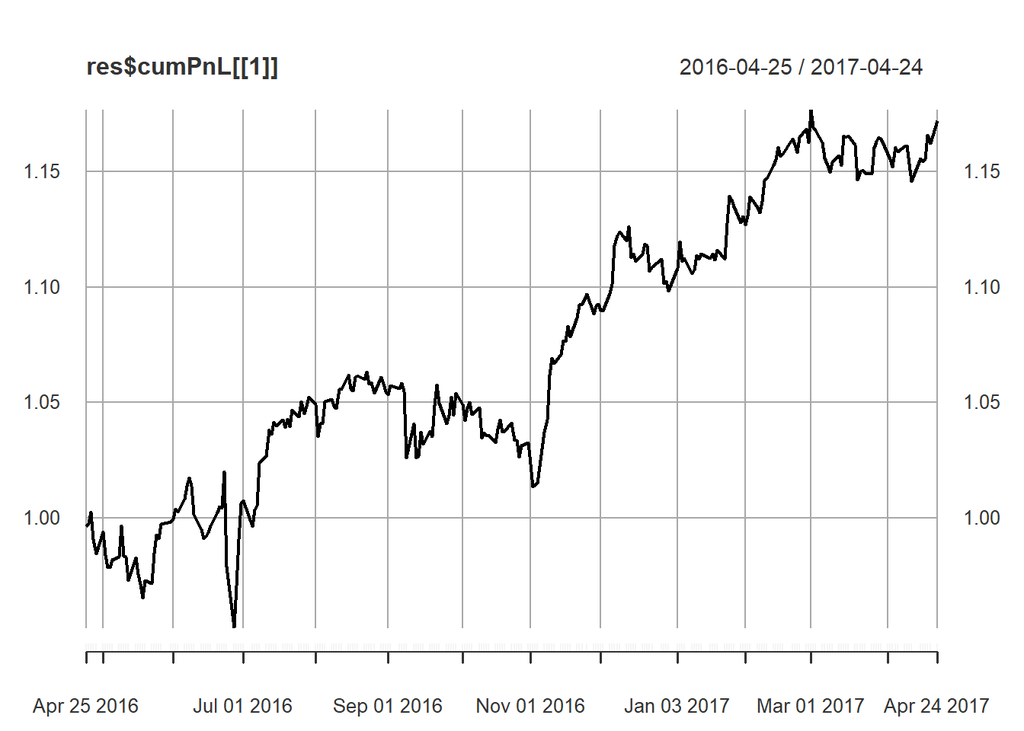

```r
plot(res$cumPnL[[1]])
```

```r
res$performance
```

```
#>       Sharpe ratio max drawdown annual return annual volatility
#> data1     1.467109   0.06642285     0.1720106         0.1172446
#>       Sterling ratio Omega ratio  ROT bps
#> data1        2.58963    1.280153 2871.655
```

Let’s try with a slightly more sophisticated portfolio design, like the global minimum variance portfolio (GMVP):

```r
GMVP_portfolio_fun <- function(data) {
  X <- diff(log(data$adjusted))[-1]  # compute log returns
  Sigma <- cov(X)  # compute SCM
  # design GMVP
  w <- solve(Sigma, rep(1, nrow(Sigma)))
  w <- w/sum(abs(w))  # it may not satisfy w>=0
  return(w)
}
bt <- portfolioBacktest(GMVP_portfolio_fun, dataset[1])
res <- backtestSelector(bt, portfolio_index = 1)
res$error
```

```
#> data1
#>  TRUE
```

```r
res$error_message
```

```
#> $data1
#> [1] "No-shortselling constraint not satisfied."
```

Indeed, the GMVP does not satisfy the no-shortselling constraint. We can repeat the backtesting indicating that shortselling is allowed:

```r
bt <- portfolioBacktest(GMVP_portfolio_fun, dataset[1], shortselling = TRUE)
res <- backtestSelector(bt, portfolio_index = 1)
res$error
```

```
#> data1
#> FALSE
```

```r
res$error_message
```

```
#> $data1
#> [1] NA
```

```r
res$cpu_time
```

```
#>       data1
#> 0.003076923
```

```r
res$performance
```

```
#>       Sharpe ratio max drawdown annual return annual volatility
#> data1    0.4321617   0.02601129     0.0183104        0.04236933
#>       Sterling ratio Omega ratio  ROT bps
#> data1      0.7039406    1.075537 36.41359
```

We could be more sophisticated and design a Markowitz mean-variance portfolio satisfying the no-shortselling constraint:

```r
Markowitz_portfolio_fun <- function(data) {
  library(CVXR) #install.packages("CVXR")
  X <- as.matrix(diff(log(data$adjusted))[-1])  # compute log returns
  mu <- colMeans(X)  # compute mean vector
  Sigma <- cov(X)  # compute the SCM
  # design mean-variance portfolio
  w <- Variable(nrow(Sigma))
  prob <- Problem(Maximize(t(mu) %*% w - 0.5*quad_form(w, Sigma)),
                  constraints = list(w >= 0, sum(w) == 1))
  result <- solve(prob)
  return(as.vector(result$getValue(w)))
}
```

We can now backtest it:

```r
bt <- portfolioBacktest(Markowitz_portfolio_fun, dataset[1])
res <- backtestSelector(bt, portfolio_index = 1)
res$error
```

```
#> data1
#> FALSE
```

```r
res$error_message
```

```
#> $data1
#> [1] NA
```

```r
res$cpu_time
```

```
#> data1
#>  0.24
```

```r
res$performance
```

```
#>       Sharpe ratio max drawdown annual return annual volatility
#> data1   -0.1049306    0.2096863   -0.02058176         0.1961464
#>       Sterling ratio Omega ratio  ROT bps
#> data1    -0.09815498   0.9985759 8.583926
```

Instead of backtesting a portfolio on a single `xts` dataset, it is more meaningful to backtest it on multiple datasets. This can be easily done simply by passing a list of `xts` objects:

```r
mul_data_bt <- portfolioBacktest(Markowitz_portfolio_fun, dataset[1:5])
mul_data_res <- backtestSelector(mul_data_bt, portfolio_index = 1)
names(mul_data_res)
```

```
#> [1] "performance"   "error"         "error_message" "cpu_time"
#> [5] "portfolio"     "return"        "cumPnL"
```

```r
mul_data_res$cpu_time
```

```
#>     data1     data2     data3     data4     data5
#> 0.2307692 0.2184615 0.2176923 0.2192308 0.2223077
```

```r
mul_data_res$performance
```

```
#>       Sharpe ratio max drawdown annual return annual volatility
#> data1   -0.1049306    0.2096863   -0.02058176         0.1961464
#> data2    1.0281566    0.2334022    0.35935571         0.3495146
#> data3    1.1818257    0.1685567    0.29888243         0.2528989
#> data4    0.1904625    0.1512879    0.05060499         0.2656953
#> data5   -0.2957469    0.6467921   -0.21158243         0.7154171
#>       Sterling ratio Omega ratio    ROT bps
#> data1    -0.09815498   0.9985759   8.583926
#> data2     1.53964118   1.2101015 556.025649
#> data3     1.77318680   1.2211991 281.163758
#> data4     0.33449453   1.0537061  72.906528
#> data5    -0.32712589   1.0147774  40.755538
```

The results from backtesting on multiple datasets can be further summarized by function `backtestSummary()` based on user customized summary functions. For example, we can summarize results using `median()`

```r
res_summary <- backtestSummary(mul_data_bt, summary_fun = median)
names(res_summary)
```

```
#> [1] "performance_summary" "failure_rate"        "cpu_time_summary"
#> [4] "error_message"
```

```r
res_summary$performance_summary
```

```
#>                          fun1
#> Sharpe ratio       0.19046249
#> max drawdown       0.20968630
#> annual return      0.05060499
#> annual volatility  0.26569529
#> Sterling ratio     0.33449453
#> Omega ratio        1.05370607
#> ROT bps           72.90652820
```

## Backtesting multiple portfolios

Backtesting multiple portfolios is equally simple. It suffices to pass a list of functions to the backtesting function `portfolioBacktest()`:

```r
bt <- portfolioBacktest(list(uniform_portfolio_fun, GMVP_portfolio_fun),
                        dataset, shortselling = TRUE)
names(bt)
```

```
#> [1] "fun1" "fun2"
```

```r
res_summary <- backtestSummary(bt, summary_fun = median)
res_summary$performance_summary
```

```
#>                           fun1         fun2
#> Sharpe ratio      1.546805e+00   0.99702912
#> max drawdown      8.946477e-02   0.03914431
#> annual return     1.651707e-01   0.04777475
#> annual volatility 1.215642e-01   0.04376135
#> Sterling ratio    2.219609e+00   0.97984607
#> Omega ratio       1.296275e+00   1.19370264
#> ROT bps           2.715873e+03 115.63512029
```

We also provide another function `backtestTable()` to extract the results into matrix form.

```r
res_table <- backtestTable(bt)
names(res_table)
```

```
#>  [1] "Sharpe ratio"      "max drawdown"      "annual return"
#>  [4] "annual volatility" "Sterling ratio"    "Omega ratio"
#>  [7] "ROT bps"           "error"             "cpu_time"
#> [10] "error_message"
```

```r
res_table$`Sharpe ratio`
```

```
#>              fun1        fun2
#> data1  1.46710897  0.43216171
#> data2  0.37214279  0.45708668
#> data3  2.45729621  1.41115502
#> data4  1.25775368 -0.01951969
#> data5  0.21333697  0.72256088
#> data6  1.84467935  2.17578547
#> data7  2.58831048  4.32024112
#> data8  0.08604527  1.13401883
#> data9  1.62650187  0.86003940
#> data10 2.01062146  1.82664160
```

The results from `backtestTable()` works well with the boxplot

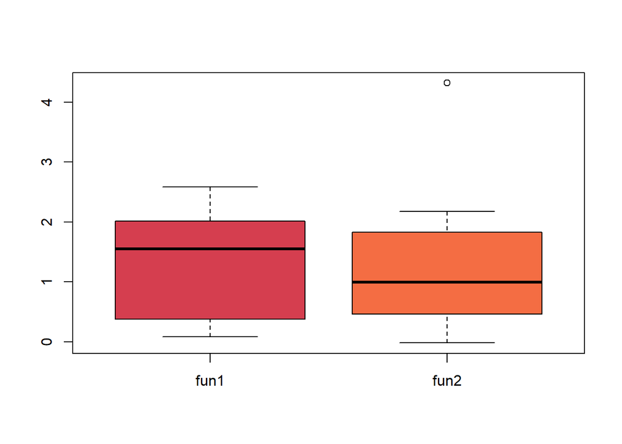

```r
library(RColorBrewer)
palette <- brewer.pal(9, "Spectral")
boxplot(res_table$`Sharpe ratio`, col=palette)
```

Note that the function names are given as `fun1` and `fun2` because only the function bodies are passed to `portfolioBacktest()`. To make the results more recognizable, we can manually pass the function names as follows:

```r
bt <- portfolioBacktest(list('my_uniform' = uniform_portfolio_fun, 'my_GMVP' = GMVP_portfolio_fun),
                        dataset[1:5], shortselling = TRUE)
names(bt)
```

```
#> [1] "my_uniform" "my_GMVP"
```

```r
res_summary <- backtestSummary(bt, summary_fun = median)
res_summary$performance_summary
```

```
#>                     my_uniform     my_GMVP
#> Sharpe ratio         1.2577537  0.45708668
#> max drawdown         0.1085410  0.04323931
#> annual return        0.1583309  0.02480846
#> annual volatility    0.1258838  0.05427518
#> Sterling ratio       1.4587189  0.67562935
#> Omega ratio          1.2505383  1.08372516
#> ROT bps           2368.6803778 60.43757407
```

## Incoporate benchmarks

When perform the backtest of our designed portfolio functions, we may want to incorporate some benchmarks. Now the package suppport two benchmarks, which are `uniform portfolio` and `index` of the certain market. We can easily do that in any case by passing corresponding value to argument `benchmark`.

```r
bt <- portfolioBacktest(list('my_uniform' = uniform_portfolio_fun, 'my_GMVP' = GMVP_portfolio_fun),
                        dataset[1:5], shortselling = TRUE, benchmark = c('uniform', 'index'))
names(bt)
```

```
#> [1] "my_uniform" "my_GMVP"    "uniform"    "index"
```

```r
res_summary <- backtestSummary(bt, summary_fun = median)
res_summary$performance_summary
```

```
#>                     my_uniform     my_GMVP      uniform     index
#> Sharpe ratio         1.2577537  0.45708668    1.2577537 0.8683934
#> max drawdown         0.1085410  0.04323931    0.1085410 0.1055529
#> annual return        0.1583309  0.02480846    0.1583309 0.1083058
#> annual volatility    0.1258838  0.05427518    0.1258838 0.1247198
#> Sterling ratio       1.4587189  0.67562935    1.4587189 1.0260806
#> Omega ratio          1.2505383  1.08372516    1.2505383 1.1880570
#> ROT bps           2368.6803778 60.43757407 2368.6803778       Inf
```